# 7 - Classification

Joseph Rickert

10/20/15

```r
library(rattle)       # data set plus plot for decision trees
library(rpart)              # CART Decision Trees
library(colorspace)     # used to generate colors for plots
library(ROCR)                 # ROC
library(rpart.plot)   # plot decision trees
```

## Some Convenience Functions

```r
# Function to divide data into training, and test sets
ttIndex <- function(data=data,pctTrain=0.7)
    {
        # fcn to create indices to divide data into random
        # training, validation and testing data sets
        N <- nrow(data)
        trainInd <<- sample(N, pctTrain*N)
        testInd <<- setdiff(seq_len(N),trainInd)
    }
# Function to generate the confusion matrix and percent correct
score <- function(model,target=data[testInd, 21],predict=pr){
    results.test <- table(target,predict,dnn=c("Actual", "Predicted"))
    pct.test.correct <- round(100 * sum(diag(results.test)) / sum(results.test),2)
    results <- list(results.test,pct.test.correct)
    (results)
}
```

## Read the Data and Prepare the Training and Test Sets

Get the weather data and select the subset for modeling

```r
name <- "weather.csv"
dataDir <- "C:/DATA/Rattle_Data"
path <- file.path(dataDir,name)
data <- read.csv(path,header=TRUE)
head(data,2)
```

```
##         Date Location MinTemp MaxTemp Rainfall Evaporation Sunshine
## 1 2007-11-01 Canberra       8    24.3      0.0         3.4      6.3
## 2 2007-11-02 Canberra      14    26.9      3.6         4.4      9.7
##   WindGustDir WindGustSpeed WindDir9am WindDir3pm WindSpeed9am
## 1          NW            30         SW         NW            6
## 2         ENE            39          E          W            4
##   WindSpeed3pm Humidity9am Humidity3pm Pressure9am Pressure3pm Cloud9am
## 1           20          68          29      1019.7      1015.0        7
## 2           17          80          36      1012.4      1008.4        5
##   Cloud3pm Temp9am Temp3pm RainToday RISK_MM RainTomorrow
## 1        7    14.4    23.6        No     3.6          Yes
## 2        3    17.5    25.7       Yes     3.6          Yes
```

```r
# Select variables for the model
data <- subset(data,select=c(MinTemp:RainToday,RainTomorrow))
set.seed(42)                                    # Set seed
ttIndex(data) # Pick out rows (index into data) for the training and test data sets
```

## Build a Tree Model with rpart

The rpart algorithm based on recursive partitioning  
(See section 11.2 of Data Mining with Rattle and R by williams)  
The rpart Algorithm:  
1. - Partition the data set according to some criterion of “best” partition  
2. - Do the same for each of the two new subsets  
3. - Once a partition is made, stick with it (greedy approach)

Measures of “best” partition:  
1. - information gain (the default)  
2. - Gini

Information Gain Algorithm:  
For all possible splits (partitions)  
1. - Split data, D, into to subsets S1 and S2 where D = S1 U S2  
2. - Calculate information I1 and I2 associated with S1 and S2  
3. - Compute total information of split: Info(D,S1,S2) = (|D1|/D)*I1 + (|D2|/|D|)*I2  
4. - Compute the information gain of the split: info(D) - info(D,S1,S2)  
5. - Select split with greatest information gain

### Build a classification tree model

```r
form <- formula(RainTomorrow ~ .)               # Describe the model to R
model <- rpart(formula=form,data=data[trainInd,])   # Build the model
model
```

```
## n= 256
##
## node), split, n, loss, yval, (yprob)
##       * denotes terminal node
##
## 1) root 256 41 No (0.83984375 0.16015625)
##   2) Pressure3pm>=1011.9 204 16 No (0.92156863 0.07843137)
##     4) Cloud3pm< 7.5 195 10 No (0.94871795 0.05128205) *
##     5) Cloud3pm>=7.5 9  3 Yes (0.33333333 0.66666667) *
##   3) Pressure3pm< 1011.9 52 25 No (0.51923077 0.48076923)
##     6) Sunshine>=8.85 25  5 No (0.80000000 0.20000000) *
##     7) Sunshine< 8.85 27  7 Yes (0.25925926 0.74074074) *
```

### Interpreting the Model Results

Every line of the output the follows will have  
1. node: a node number  
2. split: the logic for how the node splits the data  
3. n: the number of observations considered at that split  
4. loss: the number of incorrectly classified observations  
5. the majority class at that node  
6. yprob: the distribution of classes at that node

So for the second line above: Pressure3pm>=1011.9 204 16 No (0.92156863 0.07843137)  
1. node: 2)  
2. split: if Pressure3pm > 1011.9 go left down tree  
3. n: 204 obversations went down this branch  
4. loss: 16 misclassified observations  
5. Most observations were No  
6. 92% of obs have target var No, 8% are yes

### Examine the results

```r
printcp(model)
```

```
##
## Classification tree:
## rpart(formula = form, data = data[trainInd, ])
##
## Variables actually used in tree construction:
## [1] Cloud3pm    Pressure3pm Sunshine
##
## Root node error: 41/256 = 0.16016
##
## n= 256
##
##         CP nsplit rel error  xerror    xstd
## 1 0.158537      0   1.00000 1.00000 0.14312
## 2 0.073171      2   0.68293 0.92683 0.13874
## 3 0.010000      3   0.60976 0.82927 0.13244
```

```r
summary(model)
```

```
## Call:
## rpart(formula = form, data = data[trainInd, ])
##   n= 256
##
##           CP nsplit rel error    xerror      xstd
## 1 0.15853659      0 1.0000000 1.0000000 0.1431223
## 2 0.07317073      2 0.6829268 0.9268293 0.1387446
## 3 0.01000000      3 0.6097561 0.8292683 0.1324378
##
## Variable importance
##   Pressure3pm      Cloud3pm   Pressure9am      Sunshine   Humidity3pm
##            20            16            14            14            10
##      Rainfall      Cloud9am   Humidity9am       MinTemp       Temp9am
##             8             6             6             3             2
## WindGustSpeed  WindSpeed3pm
##             2             2
##
## Node number 1: 256 observations,    complexity param=0.1585366
##   predicted class=No   expected loss=0.1601562  P(node) =1
##     class counts:   215    41
##    probabilities: 0.840 0.160
##   left son=2 (204 obs) right son=3 (52 obs)
##   Primary splits:
##       Pressure3pm   < 1011.9  to the right, improve=13.415450, (0 missing)
##       Cloud3pm      < 7.5     to the left,  improve= 9.492188, (0 missing)
##       Pressure9am   < 1016.35 to the right, improve= 9.143157, (0 missing)
##       Sunshine      < 6.45    to the right, improve= 8.989766, (2 missing)
##       WindGustSpeed < 64      to the left,  improve= 7.339410, (2 missing)
##   Surrogate splits:
##       Pressure9am   < 1013.3  to the right, agree=0.938, adj=0.692, (0 split)
##       MinTemp       < 16.15   to the left,  agree=0.824, adj=0.135, (0 split)
##       Temp9am       < 20.35   to the left,  agree=0.816, adj=0.096, (0 split)
##       WindGustSpeed < 64      to the left,  agree=0.812, adj=0.077, (0 split)
##       WindSpeed3pm  < 34      to the left,  agree=0.812, adj=0.077, (0 split)
##
## Node number 2: 204 observations,    complexity param=0.07317073
##   predicted class=No   expected loss=0.07843137  P(node) =0.796875
##     class counts:   188    16
##    probabilities: 0.922 0.078
##   left son=4 (195 obs) right son=5 (9 obs)
```

[output cut: 33 more lines]

```
##
## Node number 5: 9 observations
##   predicted class=Yes  expected loss=0.3333333  P(node) =0.03515625
##     class counts:     3     6
##    probabilities: 0.333 0.667
##
## Node number 6: 25 observations
##   predicted class=No   expected loss=0.2  P(node) =0.09765625
##     class counts:    20     5
##    probabilities: 0.800 0.200
##
## Node number 7: 27 observations
##   predicted class=Yes  expected loss=0.2592593  P(node) =0.1054688
##     class counts:     7    20
##    probabilities: 0.259 0.741
```

```r
leaf <-model$where                         # find out in which leaf each observation ended up
head(leaf,20)
```

```
## 335 343 105 302 233 188 266  49 236 252 163 256 331  91 356 330 365  42
##   3   3   7   3   3   3   3   4   3   3   3   3   3   3   3   3   3   3
## 166 195
##   3   3
```

### Plot the Tree

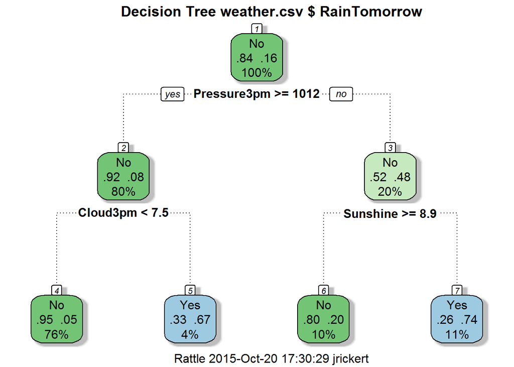

```r
fancyRpartPlot(model)
title(main="Decision Tree weather.csv $ RainTomorrow",line=3)
```

### Evaluate model performance on the test set

Run the tree model on the test set and generate an error matrix

```r
  pr <- predict(model, data[testInd, ], type="class")
#
score(model)                     # generate the confusion matrix
```

```
## [[1]]
##       Predicted
## Actual No Yes
##    No  74  11
##    Yes 10  15
##
## [[2]]
## [1] 80.91
```

### Draw the ROC Curve

First, create a prediction object.

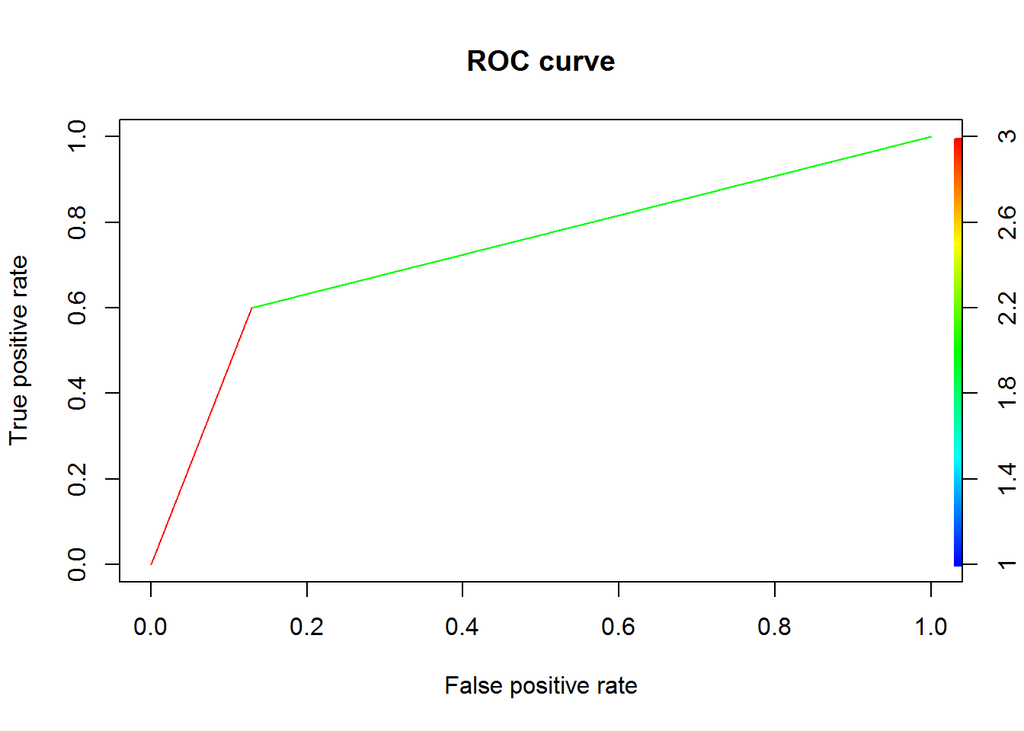

```r
pred <- prediction(as.vector(as.numeric(pr)), data[testInd,21])
perf <- performance(pred,"tpr","fpr")
plot(perf, main="ROC curve", colorize=T)
```

### Explore an unpruned tree

The complexity parameter sets the minimum benefit that must be gained at each split of the decision tree. (default = .01) Typical behavior with cp=0 is to see the error reate decrease at first and then begin to increase.

```r
control <- rpart.control(cp=0,
                         minsplit=10,
                         minbucket=0,
                         maxdepth=20,
                         usesurrogate=0,
                         maxsurrogate=0)
model2 <- rpart(formula=form,control=control,data=data[trainInd,])
print(model2$cptable)
```

```
##           CP nsplit rel error    xerror      xstd
## 1 0.15853659      0 1.0000000 1.0000000 0.1431223
## 2 0.07317073      2 0.6829268 0.7560976 0.1273117
## 3 0.06097561      3 0.6097561 0.8048780 0.1307692
## 4 0.04878049      5 0.4878049 0.8048780 0.1307692
## 5 0.02439024      7 0.3902439 0.7560976 0.1273117
## 6 0.01219512     10 0.3170732 0.9756098 0.1416945
## 7 0.00000000     14 0.2682927 1.0975610 0.1485401
```

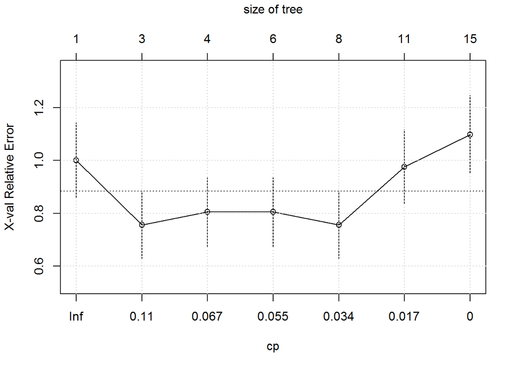

```r
plotcp(model2)
grid()
```